# Tutorial 7: Introduction to Data Analysis

Programming for Engineers (ENGG1001)

Published

June 25, 2026

## Overview

This tutorial analyses a 30-year time series of modelled daily ows in and out of Somerset and Wivenhoe reservoirs (Figure 1). These reservoirs provide water supply and ood mitigation to Brisbane. Catchment inflows are modelled as a single value for each reservoir: “Somerset inflows” for Somerset, and “Upper Brisbane River” for Wivenhoe. Wivenhoe also receives water from Somerset (i.e.“Somerset outflow”)

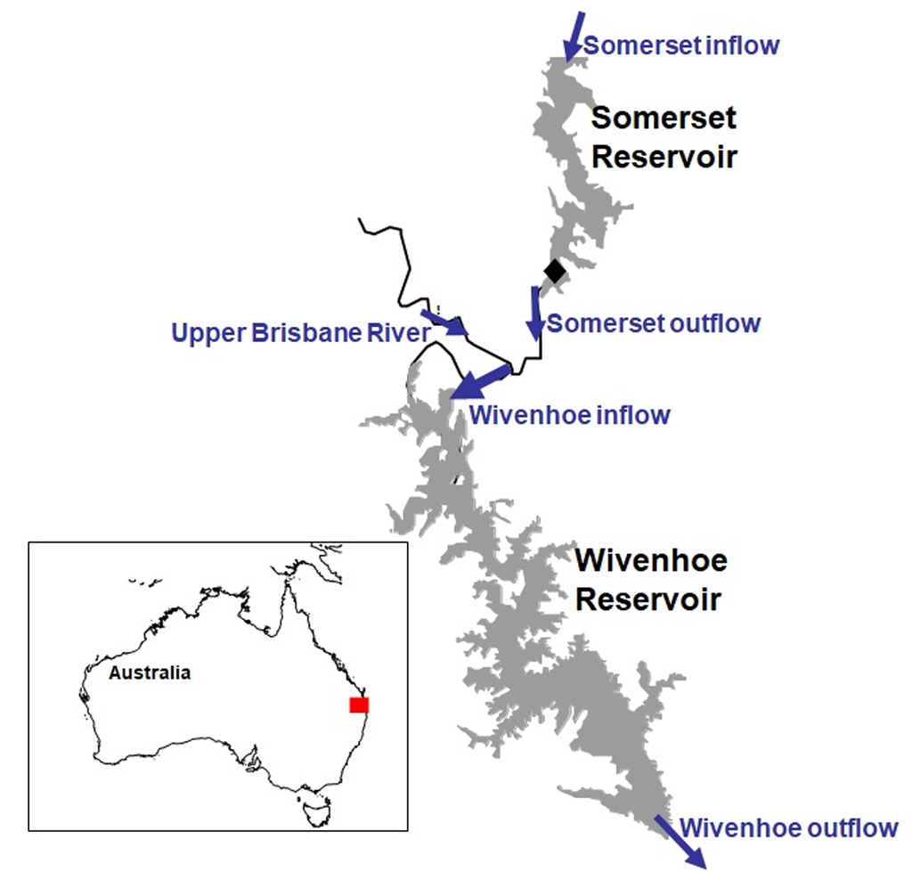

Figure 1: Wivenhoe Reservoir

# Tutorial Tasks

- Task 1: Loading Data with NumPy
- Task 2: Accessing Data Elements in NumPy Arrays
- Task 3: Filtering Data in NumPy Arrays
- Task 4: Basic Data Analysis with NumPy

## Task 1: Loading Data with NumPy

In this task, you will learn how to load data from a CSV file into a NumPy array. First download the dataset `flows.csv` down below using the top right button.

```
flows.csv
```

```
Date,"Somerset inflow, ML","Somerset outflow, ML","Upper Brisbane River, ML","Wivenhoe outflow, ML"
1980-01-01,0,225.4086129,0,676.2258065
1980-01-02,0,225.4086129,0,676.2258065
1980-01-03,0,225.4086129,0,676.2258065
1980-01-04,0,225.4086129,0,676.2258065
... (11045 more lines)
```

Next write a function called `load_flow_data(filename: str)` that takes in a filename as a input and returns 2 numpy arrays: one for the timestamps and one for the flow rates. Here is an example of how the function should work:

timestamps, flow_rates = load_flow_data("resources/flows.csv")

timestamps[0:5]

array(['1980-01-01', '1980-01-02', '1980-01-03', '1980-01-04',

'1980-01-05'], dtype='datetime64[D]')

flow_rates[0:5]

array([[ 0. , 225.4086129, 0. , 676.2258065],

[ 0. , 225.4086129, 0. , 676.2258065],

[ 0. , 225.4086129, 0. , 676.2258065],

[ 0. , 225.4086129, 0. , 676.2258065],

[ 0. , 225.4086129, 0. , 676.2258065]])

**Tip**

**HINT**: you can use the function `np.loadtxt()` to load the data from the CSV file. Look up the documentation for this function to see how to use it. In particular, look at the description of the parameters `delimiter`, `skiprows`, `usecols`, and `dtype`. You may need to call this function twice to get the two separate arrays.

Also Make sure that `flows.csv` is in the same directory as your code file, or provide the correct relative path to the file when calling your function. In this particular case, our file is in the `resources` folder, so we need to include that in the path when calling the function.

**Callout-answer**Answer**

```
load_data.py
```

```python
import numpy as np

def load_flow_data(filename: str) -> tuple[np.ndarray, np.ndarray]:
    """Load flow data from a CSV file.

    Parameters
    ----------
    filename : str
        The path to the CSV file containing flow data.

    Returns
    -------
    timestamps : np.ndarray
        An array of timestamps.
    flows : np.ndarray
        A 2D array of flow rates.
    """
    timestamps = np.loadtxt(filename, delimiter=',', skiprows=1,
                            usecols=0, dtype=np.datetime64)
    flows = np.loadtxt(filename, delimiter=',', skiprows=1,
                       usecols=(1,2,3,4))
    return timestamps, flows

# in this case the file is in the resources folder
timestamps, flow_rates = load_flow_data("resources/flows.csv")
print(timestamps[0:5])
print(flow_rates[0:5])
```

Output

```
['1980-01-01' '1980-01-02' '1980-01-03' '1980-01-04' '1980-01-05']
[[  0.        225.4086129   0.        676.2258065]
 [  0.        225.4086129   0.        676.2258065]
 [  0.        225.4086129   0.        676.2258065]
 [  0.        225.4086129   0.        676.2258065]
 [  0.        225.4086129   0.        676.2258065]]
```

## Task 2: Accessing Data Elements in NumPy Arrays

In this task, you will learn how to access specific elements in a NumPy array. First write a function called `split_flows(flow_rates: np.ndarray)` that takes in the flow rates array and returns four separate arrays, one for each column of flow rates. Here is an example of how the function should work:

s_in, s_out, ubr, w_out = split_flows(flow_rates)

s_in[0:5]

array([0., 0., 0., 0., 0.])

s_out[0:5]

array([225.4086129, 225.4086129, 225.4086129, 225.4086129, 225.4086129])

ubr[0:5]

array([0., 0., 0., 0., 0.])

w_out[0:5]

array([676.2258065, 676.2258065, 676.2258065, 676.2258065, 676.2258065])

**Callout-answer**Answer**

```
split_flows.py
```

```python
def split_flows(flow_rates: np.ndarray) \
    -> tuple[np.ndarray, np.ndarray, np.ndarray, np.ndarray]:
    """Split flow rates into separate arrays for each column.

    Parameters
    ----------
    flow_rates : np.ndarray
        A 2D array of flow rates.

    Returns
    -------
    s_in : np.ndarray
        Somerset inflows.
    s_out : np.ndarray
        Somerset outflows.
    ubr : np.ndarray
        Upper Brisbane River inflows.
    w_out : np.ndarray
        Wivenhoe outflows.
    """
    s_in = flow_rates[:, 0]
    s_out = flow_rates[:, 1]
    ubr = flow_rates[:, 2]
    w_out = flow_rates[:, 3]
    return s_in, s_out, ubr, w_out

s_in, s_out, ubr, w_out = split_flows(flow_rates)
print(s_in[0:5])
print(s_out[0:5])
print(ubr[0:5])
print(w_out[0:5])
```

Output

```
[0. 0. 0. 0. 0.]
[225.4086129 225.4086129 225.4086129 225.4086129 225.4086129]
[0. 0. 0. 0. 0.]
[676.2258065 676.2258065 676.2258065 676.2258065 676.2258065]
```

Write a function called `get_flow_on_date(timestamps: np.ndarray, flow: np.ndarray, date: str)` that takes in the timestamps array, the flow rates array, and a date string in the format ‘YYYY-MM-DD’, and returns the corresponding flow rate(s) for that date. Here is an example of how the function should work:

flow_on_date = get_flow_on_date(timestamps, s_in, '1990-01-01')

flow_on_date

array([65.33160306])

**Callout-answer**Answer**

```
get_flow_on_date.py
```

```python
def get_flow_on_date(timestamps: np.ndarray, flow: np.ndarray, date: str) \
    -> np.ndarray:
    """Get flow rates for a specific date.

    Parameters
    ----------
    timestamps : np.ndarray
        An array of timestamps.
    flow : np.ndarray
        An array of flow rates.
    date : str
        The date string in 'YYYY-MM-DD' format.

    Returns
    -------
    np.ndarray
        The flow rates for the specified date.
    """
    date_np = np.datetime64(date)
    return flow[timestamps == date_np]

flow_on_date = get_flow_on_date(timestamps, s_in, '1990-01-01')
print(flow_on_date)
```

Output

```
[65.33160306]
```

## Task 3: Filtering Data in NumPy Arrays

In this task, you will learn how to filter data in a NumPy array based on certain conditions.

In data science, there are often “invalid values” that don’t make sense in the context of the data. For example, negative flow rates are not physically possible. Write a function called `filter_invalid_flows(flow: np.ndarray)` that takes in a flow rates array and returns a new array with all negative values replaced with `np.nan`. It should also print the number of invalid values that were removed. Here is an example of how the function should work:

s_in[-15:]

array([ 2223.75043 , 2098.490933 , 1759.794771 , -156000. ,

1547.216763 , 1469.82675 , 1249.412976 , 1300.043289 ,

1091.69408 , 1013.060882 , 943.3688869, 881.4713249,

1049.25583 , 809.5350978, 806.7261736])

filtered_s_in = filter_invalid_flows(s_in)

Number of invalid values removed: 1

filtered_s_in[-15:]

array([2223.75043 , 2098.490933 , 1759.794771 , nan,

1547.216763 , 1469.82675 , 1249.412976 , 1300.043289 ,

1091.69408 , 1013.060882 , 943.3688869, 881.4713249,

1049.25583 , 809.5350978, 806.7261736])

**Callout-answer**Answer**

```
filter_invalid_flows.py
```

```python
def filter_invalid_flows(flow: np.ndarray) -> np.ndarray:
    """Filter invalid flow rates by replacing negative values with np.nan.

    Parameters
    ----------
    flow : np.ndarray
        An array of flow rates.

    Returns
    -------
    np.ndarray
        The filtered array with negative values replaced by np.nan.
    """
    invalid_count = np.sum(flow < 0)
    print(f"Number of invalid values removed: {invalid_count}")
    filtered_flow = flow.copy()
    filtered_flow[filtered_flow < 0] = np.nan
    return filtered_flow

print(s_in[-15:])
filtered_s_in = filter_invalid_flows(s_in)
print(filtered_s_in[-15:])
```

Output

```
[   2223.75043      2098.490933     1759.794771  -156000.
    1547.216763     1469.82675      1249.412976     1300.043289
    1091.69408      1013.060882      943.3688869     881.4713249
    1049.25583       809.5350978     806.7261736]
Number of invalid values removed: 1
[2223.75043   2098.490933  1759.794771           nan 1547.216763
 1469.82675   1249.412976  1300.043289  1091.69408   1013.060882
  943.3688869  881.4713249 1049.25583    809.5350978  806.7261736]
```

Write another function called `get_high_flow_days(timestamps: np.ndarray, flow: np.ndarray, threshold: float)` that takes in the timestamps array, a flow rates array, and a threshold value, and returns an array of timestamps where the flow rate exceeds the threshold. Here is an example of how the function should work:

high_flow_days = get_high_flow_days(timestamps, w_out, 5000.0)

high_flow_days.size

329

**Callout-answer**Answer**

```
get_high_flow_days.py
```

```python
def get_high_flow_days(timestamps: np.ndarray, flow: np.ndarray, threshold: float) \
    -> np.ndarray:
    """Get timestamps where flow rates exceed a threshold.

    Parameters
    ----------
    timestamps : np.ndarray
        An array of timestamps.
    flow : np.ndarray
        An array of flow rates.
    threshold : float
        The flow rate threshold.

    Returns
    -------
    np.ndarray
        An array of timestamps where flow rates exceed the threshold.
    """
    return timestamps[flow > threshold]

high_flow_days = get_high_flow_days(timestamps, w_out, 5000.0)
print(high_flow_days.size)
```

Output

```
329
```

## Task 4: Basic Data Analysis with NumPy

In this task, you will learn how to perform basic data analysis using NumPy functions.

Write a function called `calculate_statistics(flow: np.ndarray)` that takes in a flow rates array and returns the mean, median, and standard deviation of the flow rates, ignoring any `np.nan` values. Here is an example of how the function should work:

mean, median, std_dev = calculate_statistics(filtered_s_in)

mean, median, std_dev

(np.float64(958.4525974683788), np.float64(140.2254003), np.float64(5377.917485770079))

**Tip**

**HINT**: Have a look at the NumPy functions `np.nanmean()`, `np.nanmedian()`, and `np.nanstd()`. How could they be useful here?

**Callout-answer**Answer**

```
calculate_statistics.py
```

```python
def calculate_statistics(flow: np.ndarray) \
    -> tuple[float, float, float]:
    """Calculate mean, median, and standard deviation of flow rates.

    Parameters
    ----------
    flow : np.ndarray
        An array of flow rates.

    Returns
    -------
    mean : float
        The mean flow rate.
    median : float
        The median flow rate.
    std_dev : float
        The standard deviation of the flow rates.
    """
    mean = np.nanmean(flow)
    median = np.nanmedian(flow)
    std_dev = np.nanstd(flow)
    return mean, median, std_dev

mean, median, std_dev = calculate_statistics(filtered_s_in)
print(mean, median, std_dev)
```

Output

```
958.4525974683788 140.2254003 5377.917485770079
```